# Tugas 4

17 September 2026

**Putri Dwi Suci Sri Mulyaningsih Sitanggang** (M0401241033)

## 0.1 White Noise

Pembangkitan data berpola AR, MA, ARMA, dan banyak proses deret waktu lainnya diawali pembangkitan *white noise*. *White noise* merupakan sederet nilai dari peubah bebas stokastik identik. Oleh karena itu, *white noise* memiliki dua karakteristik penting:

1. *White noise* tidak memiliki autokorelasi (**karena saling bebas**)
2. Nilai harapan dan ragam *white noise* sama (**karena berasal dari peubah acak bebas stokastik identik**)

*White noise* dibangkitkan dari suatu peubah acak, umumnya peubah acak normal.

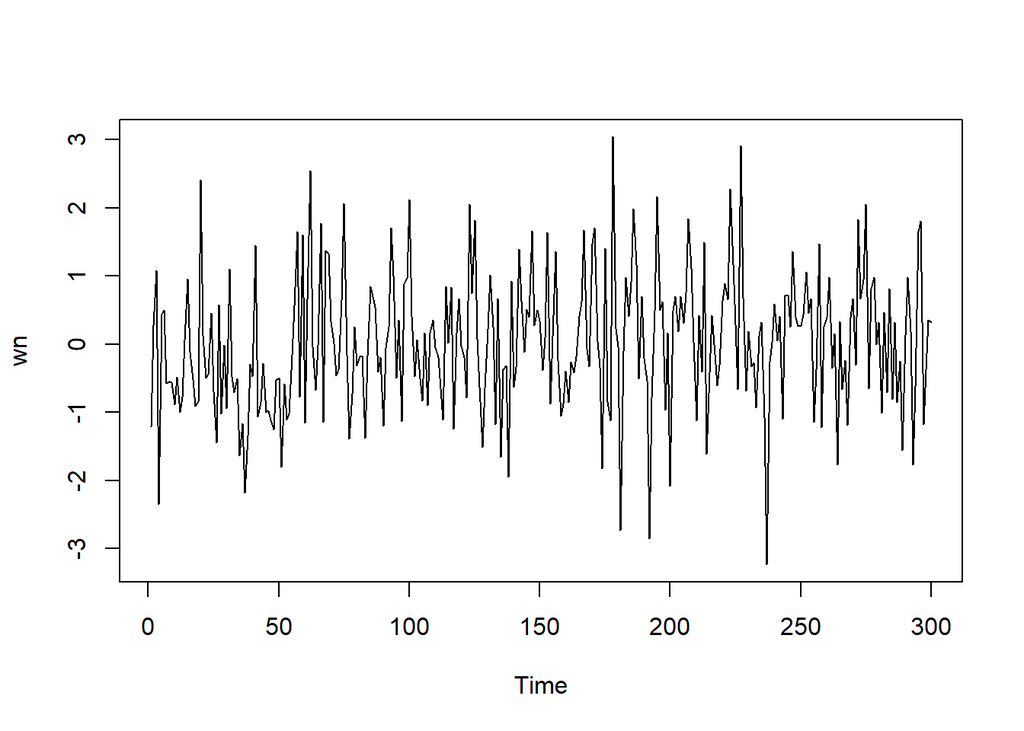

```r
set.seed(1234)
wn <- rnorm(300)
ts.plot(wn)
```

Dapat terlihat bahwa *white noise* tidak memiliki autokorelasi dari ACF. Perhatikan bahwa lag ke-0 adalah korelasi observasi ke-t dengan dirinya sendiri. Nilai korelasi tersebut pasti 1. Sebagai alternatif, lag pertama di plot ACF dapat ditetapkan sebagai 1 (alih-alih 0) dengan menambahkan argumen `xlim(1, lag akhir)`. Plot tersebut dapat disandingkan bersamaan dengan membuat matriks $1 \times 2$ dengan `par(mfrow = c(1,2))`.

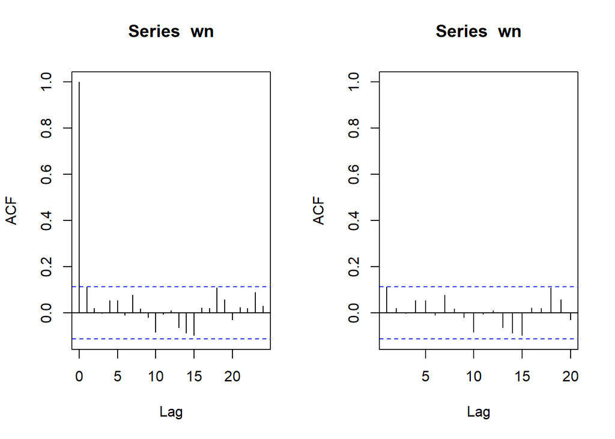

```r
par(mfrow = c(1, 2))
acf(wn)
acf(wn, xlim = c(1, 20))
```

# 1 Proses MA(2)

Proses MA(2) dengan $\theta_1 = 0.4$ dan $\theta_2 = 0.6$:

$$y_t = e_t + \theta_1 e_{t-1} + \theta_2 e_{t-2}$$

## 1.1 Pembangkitan Manual

```r
set.seed(1234)
ma2 <- wn[1]
ma2[2] <- wn[2] + 0.4*wn[1]
for(i in 3:300){
   ma2[i] <- wn[i] + 0.4*wn[i-1] + 0.6*wn[i-2]
}
ma2
```

```
##   [1] -1.207065749 -0.205397058  0.471173424 -1.745463687  0.141510314
##   [6] -0.729712854 -0.114842790 -0.472894305 -1.127948717 -1.443797742
##  [11] -1.171879031 -1.723286222 -1.461924092 -0.845074607  0.519525249
##  [16]  0.312187420  0.020572732 -1.181770516 -1.508255550  1.534249256
##  [21]  0.598119283  1.012450498 -0.556369299 -0.011041246 -0.774213194
##  [26] -1.449939345 -0.420758391 -1.662676381 -0.079747157 -1.556197355
##  [31]  0.718835126 -0.596243221 -0.238298741 -1.070389923 -2.255260716
##  [36] -2.120011486 -3.624543435 -2.913580609 -2.138714925 -1.388210999
##  [41]  1.086560934 -0.768382742 -0.413123964 -1.263954490 -1.619808057
##  [46] -1.534624150 -2.091327966 -2.276021753 -1.689013389 -1.457572736
##  [51] -2.319068111 -1.602598402 -2.425338748 -1.807763414 -1.233628102
##  [56] -0.110845196  1.775654086  0.223607057  2.285258743 -0.979456751
##  [61]  1.157010823  2.116941328  1.378789117  0.845856907 -0.296314421
##  [66]  1.372262398 -0.432336811  1.978634754  1.193531021  1.688995021
##  [71]  0.939220832 -0.250827924 -0.544575725  0.228395751  2.109671129
```

[output cut: 45 more lines]

## 1.2 Pembangkitan dengan `arima.sim()`

```r
set.seed(1234)
ma2.sim <- arima.sim(list(order=c(0,0,2), ma=c(0.4,0.6)), n=300)
ma2.sim
```

```
## Time Series:
## Start = 1
## End = 300
## Frequency = 1
##   [1]  0.471173424 -1.745463687  0.141510314 -0.729712854 -0.114842790
##   [6] -0.472894305 -1.127948717 -1.443797742 -1.171879031 -1.723286222
##  [11] -1.461924092 -0.845074607  0.519525249  0.312187420  0.020572732
##  [16] -1.181770516 -1.508255550  1.534249256  0.598119283  1.012450498
##  [21] -0.556369299 -0.011041246 -0.774213194 -1.449939345 -0.420758391
##  [26] -1.662676381 -0.079747157 -1.556197355  0.718835126 -0.596243221
##  [31] -0.238298741 -1.070389923 -2.255260716 -2.120011486 -3.624543435
##  [36] -2.913580609 -2.138714925 -1.388210999  1.086560934 -0.768382742
##  [41] -0.413123964 -1.263954490 -1.619808057 -1.534624150 -2.091327966
##  [46] -2.276021753 -1.689013389 -1.457572736 -2.319068111 -1.602598402
##  [51] -2.425338748 -1.807763414 -1.233628102 -0.110845196  1.775654086
```

[output cut: 49 more lines]

## 1.3 Karakteristik MA(2)

### 1.3.1 Plot Time Series

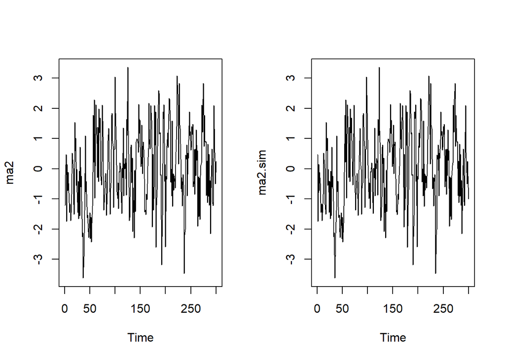

```r
par(mfrow = c(1, 2))
ts.plot(ma2)
ts.plot(ma2.sim)
```

```r
par(mfrow = c(1, 1))
```

Berdasarkan plot time series tersebut, terlihat bahwa data MA(2) yang dibangkitkan berfluktuasi di sekitar nilai tengah yang konstan, sehingga data **stasioner dalam rataan** (proses MA murni selalu stasioner).

### 1.3.2 Plot ACF

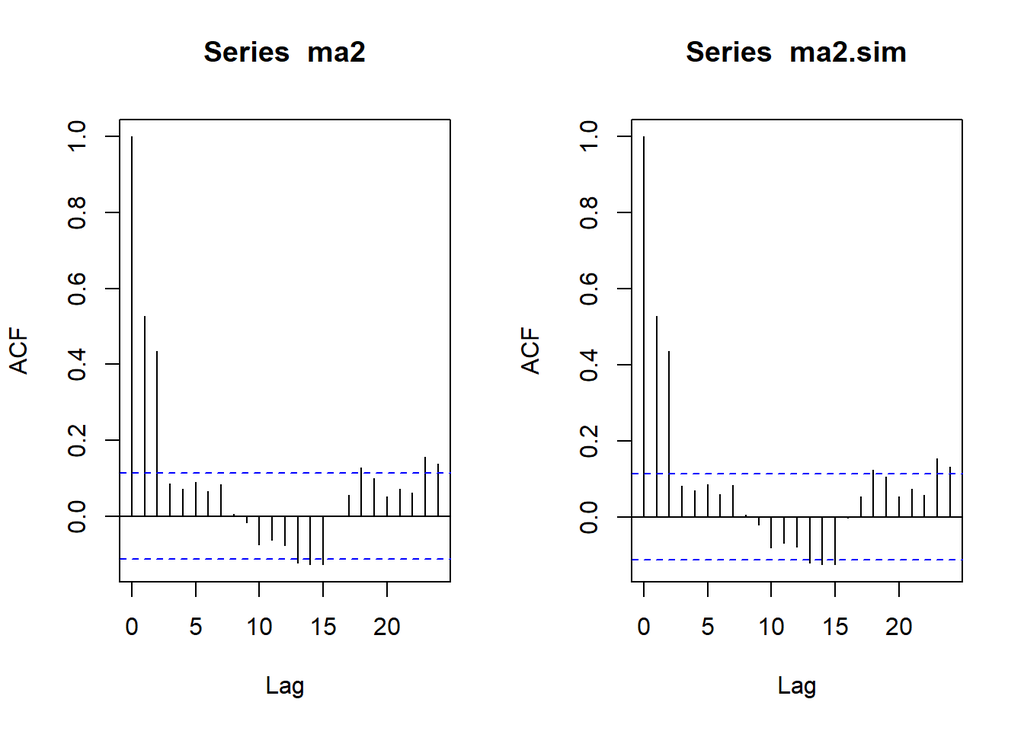

```r
par(mfrow = c(1, 2))
acf(ma2)
acf(ma2.sim)
```

```r
par(mfrow = c(1, 1))
```

Berdasarkan plot ACF tersebut, terlihat bahwa plot ACF *cuts off* setelah lag ke-2, sesuai dengan ordo MA(2).

### 1.3.3 Plot PACF

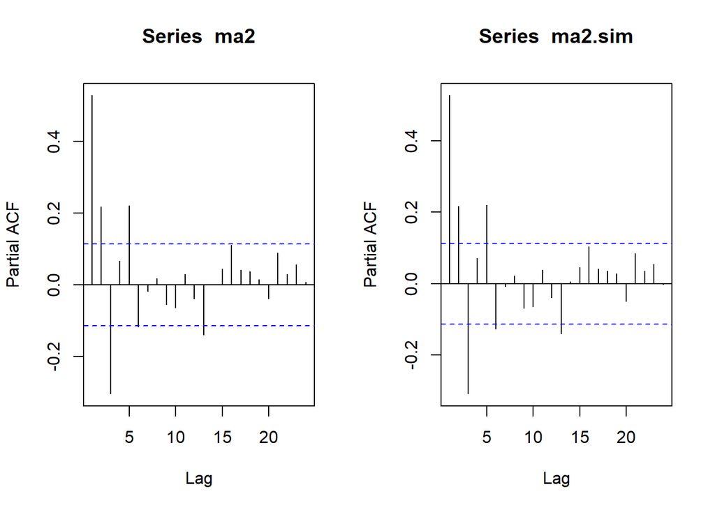

```r
par(mfrow = c(1, 2))
pacf(ma2)
pacf(ma2.sim)
```

```r
par(mfrow = c(1, 1))
```

Berdasarkan plot PACF tersebut, terlihat bahwa plot PACF cenderung *tails off*.

### 1.3.4 Plot EACF

```r
TSA::eacf(ma2)
```

```
## AR/MA
##   0 1 2 3 4 5 6 7 8 9 10 11 12 13
## 0 x x o o o o o o o o o  o  x  x
## 1 x x x o o o o o o o o  o  o  o
## 2 x x x x o o o o o o o  o  o  o
## 3 x x x x x o o o o o o  o  o  o
## 4 x x x x x o o o o o o  o  o  o
## 5 x x o x x o x o o o o  o  o  o
## 6 x x x o x o o x o o o  o  o  o
## 7 x o x o x o o x o o o  o  o  o
```

```r
TSA::eacf(ma2.sim)
```

```
## AR/MA
##   0 1 2 3 4 5 6 7 8 9 10 11 12 13
## 0 x x o o o o o o o o o  o  x  x
## 1 x x x o o o o o o o o  o  o  o
## 2 x x x x o o o o o o o  o  o  o
## 3 x x x x o o o o o o o  o  o  o
## 4 x x x x o o o o o o o  o  o  o
## 5 x x o x x o x o o o o  o  o  o
## 6 o x o o x o o x o o o  o  o  o
## 7 x o x o x o o x o o o  o  o  o
```

Berdasarkan pola segitiga nol pada plot EACF, segitiga nol berada pada ordo **AR(0) dan ordo MA(2)**, sesuai dengan model yang dibangkitkan.

## 1.4 Scatterplot Antar Lag

### 1.4.1 $Y_t$ dengan $Y_{t-1}$

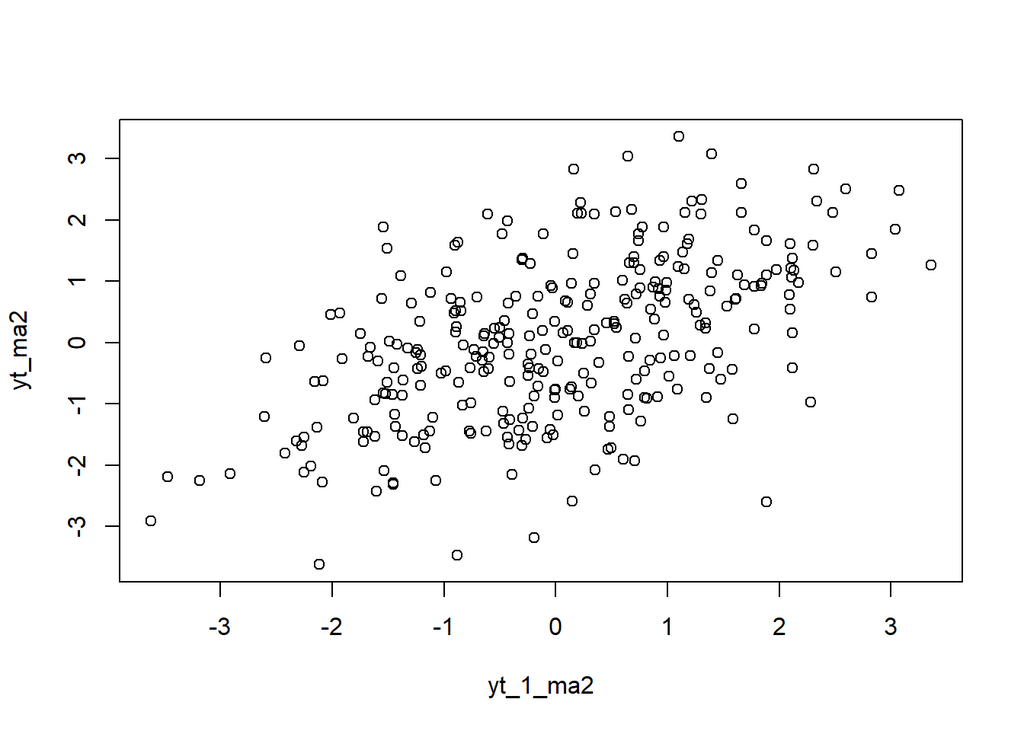

```r
yt_ma2 <- ma2[-1]
yt_1_ma2 <- ma2[-300]
plot(y=yt_ma2, x=yt_1_ma2)
```

### 1.4.2 $Y_t$ dengan $Y_{t-2}$

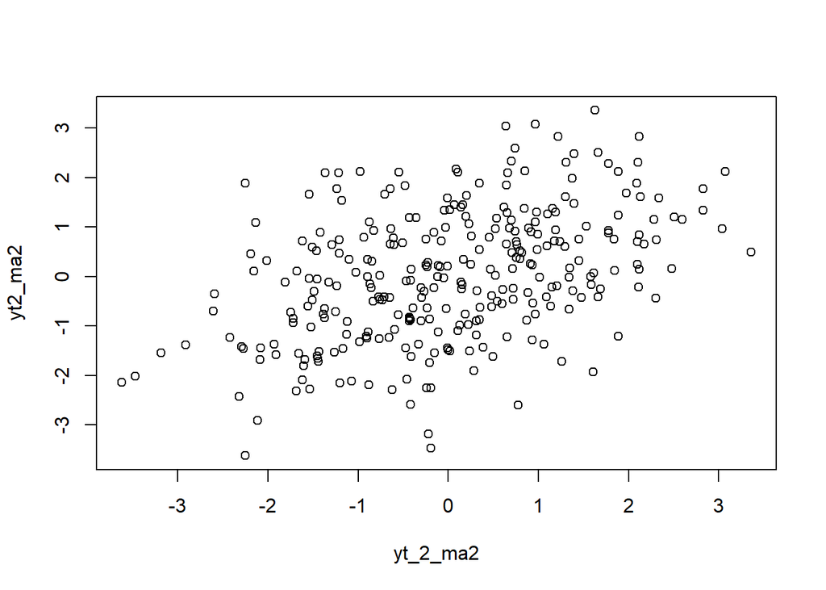

```r
yt2_ma2 <- ma2[-c(1,2)]
yt_2_ma2 <- ma2[-c(299,300)]
plot(y=yt2_ma2, x=yt_2_ma2)
```

### 1.4.3 $Y_t$ dengan $Y_{t-3}$

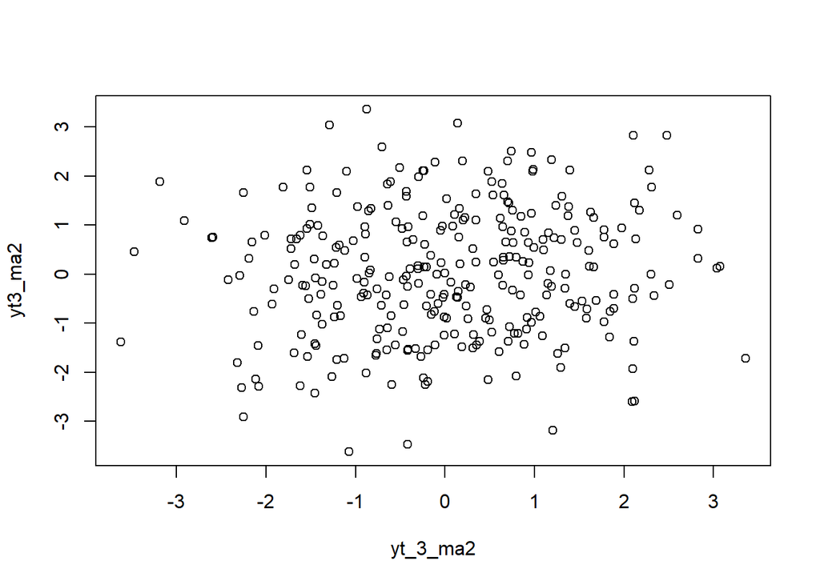

```r
yt3_ma2 <- ma2[-c(1,2,3)]
yt_3_ma2 <- ma2[-c(298,299,300)]
plot(y=yt3_ma2, x=yt_3_ma2)
```

Berdasarkan ketiga scatterplot tersebut, terlihat **hubungan positif** antara **$Y_t$ dengan $Y_{t-1}$ dan $Y_{t-2}$**, sedangkan **$Y_t$ dengan $Y_{t-3}$** cenderung **tidak menunjukkan pola hubungan** (sesuai teori MA(2) yang hanya berkorelasi hingga lag ke-2).

## 1.5 Autokorelasi MA(2)

### 1.5.1 Autokorelasi dari Data Bangkitan (Empiris)

```r
cor(yt_ma2, yt_1_ma2)     # lag 1
```

```
## [1] 0.5282201
```

```r
cor(yt2_ma2, yt_2_ma2)    # lag 2
```

```
## [1] 0.4356204
```

```r
cor(yt3_ma2, yt_3_ma2)    # lag 3
```

```
## [1] 0.08544546
```

### 1.5.2 Autokorelasi Teoritis

Untuk MA(2), autokorelasi teoritis:

$$\rho_1=\frac{\theta_1+\theta_1\theta_2}{1+\theta_1^2+\theta_2^2}, \quad
\rho_2=\frac{\theta_2}{1+\theta_1^2+\theta_2^2}, \quad
\rho_k=0 \text{ untuk } k\ge3$$

```r
ARMAacf(ma=c(0.4,0.6), lag.max=3, pacf=FALSE)
```

```
##         0         1         2         3
## 1.0000000 0.4210526 0.3947368 0.0000000
```

Terlihat bahwa nilai **autokorelasi hasil simulasi mendekati nilai autokorelasi teoritis**, dan autokorelasi pada lag ke-3 mendekati 0.

# 2 Proses AR(2)

Proses AR(2) dengan $\phi_1 = 0.5$ dan $\phi_2 = 0.2$:

$$Y_t = e_t + \phi_1 Y_{t-1} + \phi_2 Y_{t-2}$$

## 2.1 Pembangkitan Manual

```r
set.seed(1234)
n <- length(wn)
ar2 <- c(1:n)
ar2[1] <- wn[1]
ar2[2] <- wn[2] + 0.5*ar2[1]
for (i in 3:n) {
  ar2[i] <- wn[i] + 0.5*ar2[i-1] + 0.2*ar2[i-2]
}
ar2
```

```
##   [1] -1.207065749 -0.326103633  0.679976211 -2.070930324 -0.470345231
##   [6] -0.143302788 -0.740460400 -0.945522614 -1.185305386 -1.671795045
##  [11] -1.550151299 -2.107821103 -2.140194706 -1.427202757 -0.182146261
##  [16] -0.486799176 -0.790838346 -1.403974425 -1.697326562  1.286377013
##  [21]  0.437811414 -0.014504787 -0.360237983  0.276569492 -0.627483098
##  [26] -1.706632561 -0.404057179 -1.567010825 -0.879455148 -1.689078340
##  [31]  0.081867346 -0.772475074 -1.079304105 -1.195405128 -2.442656854
##  [36] -2.628028715 -3.982585377 -3.857891624 -3.019756746 -2.747354238
##  [41] -0.528132203 -1.882179673 -1.902080911 -1.608099392 -2.178805954
##  [46] -2.379537173 -2.732847970 -3.094317305 -2.617556366 -2.424491601
##  [51] -3.541788331 -2.837868410 -3.236181496 -3.200626439 -2.409859042
##  [56] -1.281998990  0.524846169 -0.767330137  1.327213794 -0.647667678
##  [61]  0.598197384  2.718556227  1.444157201  0.596156266  0.579304817
##  [66]  2.185968110  0.070237282  1.840139442  2.263681968  1.836341670
##  [71]  1.377800067  0.600699629  0.209385895  0.873119441  2.548707761
```

[output cut: 45 more lines]

## 2.2 Pembangkitan dengan `arima.sim()`

```r
set.seed(1234)
ar2.sim <- arima.sim(list(order=c(2,0,0), ar=c(0.5,0.2)), n=300)
ar2.sim
```

```
## Time Series:
## Start = 1
## End = 300
## Frequency = 1
##   [1] -1.7066325607 -0.4040571790 -1.5670108246 -0.8794551485 -1.6890783403
##   [6]  0.0818673463 -0.7724750738 -1.0793041051 -1.1954051279 -2.4426568541
##  [11] -2.6280287147 -3.9825853771 -3.8578916236 -3.0197567460 -2.7473542381
##  [16] -0.5281322030 -1.8821796728 -1.9020809107 -1.6080993919 -2.1788059544
##  [21] -2.3795371734 -2.7328479702 -3.0943173054 -2.6175563658 -2.4244916012
##  [26] -3.5417883306 -2.8378684102 -3.2361814957 -3.2006264394 -2.4098590424
##  [31] -1.2819989901  0.5248461693 -0.7673301373  1.3272137941 -0.6476676781
##  [36]  0.5981973841  2.7185562271  1.4441572006  0.5961562661  0.5793048174
##  [41]  2.1859681101  0.0702372818  1.8401394423  2.2636819683  1.8363416698
##  [46]  1.3778000670  0.6006996293  0.2093858952  0.8731194410  2.5487077608
##  [51]  1.2955793561 -0.2331697165 -0.5810507641 -0.0788975632 -0.4727180494
```

[output cut: 49 more lines]

## 2.3 Karakteristik AR(2)

### 2.3.1 Plot Time Series

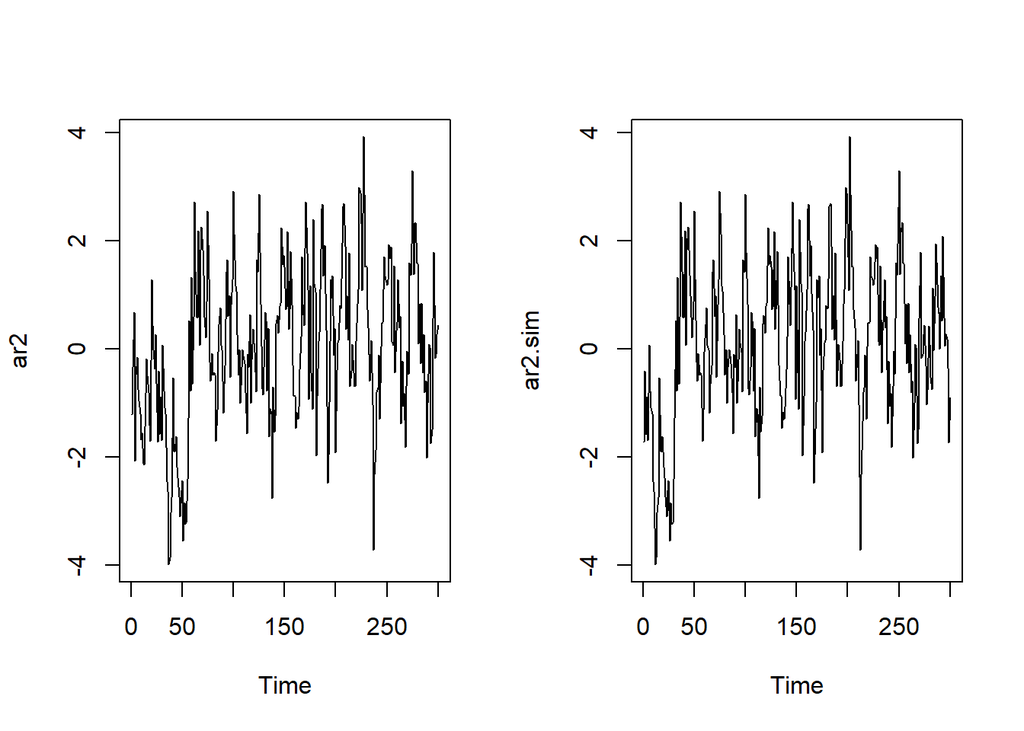

```r
par(mfrow = c(1, 2))
ts.plot(ar2)
ts.plot(ar2.sim)
```

```r
par(mfrow = c(1, 1))
```

Berdasarkan plot time series tersebut, terlihat bahwa data cenderung berfluktuasi di sekitar rataan konstan, sehingga data **stasioner dalam rataan** (kondisi kestasioneran AR(2) terpenuhi karena $\phi_1+\phi_2=0.7<1$, $\phi_2-\phi_1=-0.3<1$, dan $|\phi_2|=0.2<1$).

### 2.3.2 Plot ACF

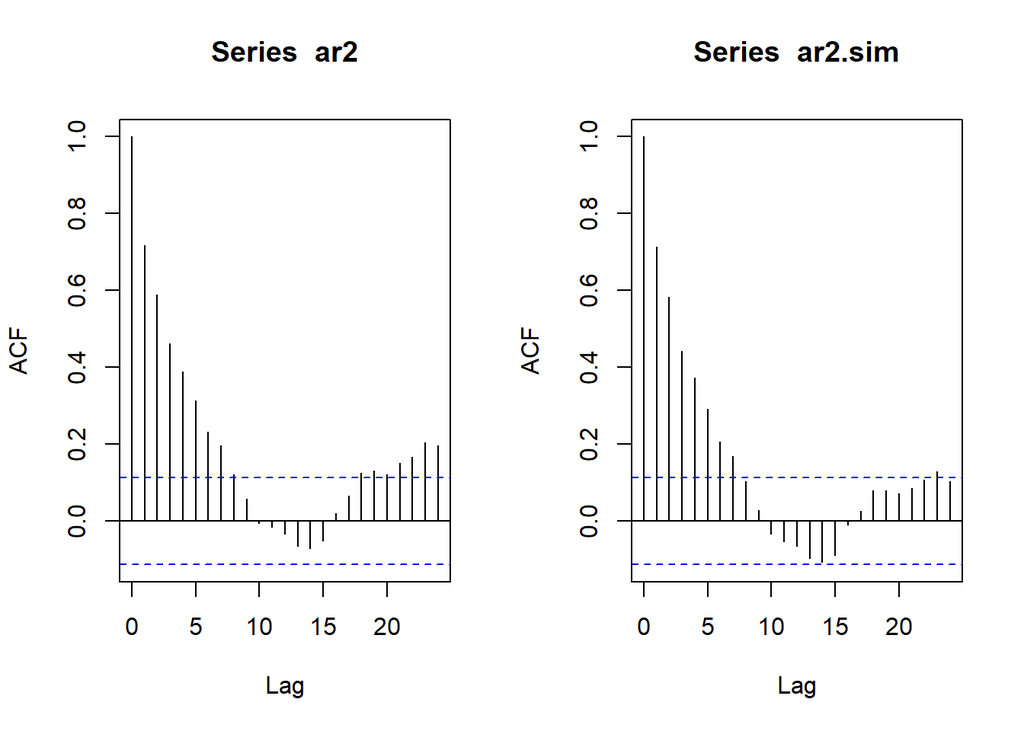

```r
par(mfrow = c(1, 2))
acf(ar2)
acf(ar2.sim)
```

```r
par(mfrow = c(1, 1))
```

Berdasarkan plot ACF tersebut, terlihat bahwa plot ACF cenderung *tails off*.

### 2.3.3 Plot PACF

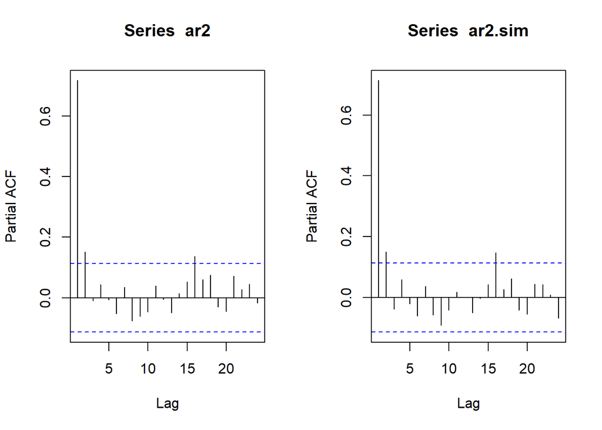

```r
par(mfrow = c(1, 2))
pacf(ar2)
pacf(ar2.sim)
```

```r
par(mfrow = c(1, 1))
```

Berdasarkan plot PACF tersebut, terlihat bahwa plot PACF *cuts off* setelah lag ke-2, sesuai dengan ordo AR(2).

### 2.3.4 Plot EACF

```r
TSA::eacf(ar2)
```

```
## AR/MA
##   0 1 2 3 4 5 6 7 8 9 10 11 12 13
## 0 x x x x x x x x o o o  o  o  o
## 1 x o o o o o o o o o o  o  o  o
## 2 o o o o o o o o o o o  o  o  o
## 3 x x o o o o o o o o o  o  o  o
## 4 x x o o o o o o o o o  o  o  o
## 5 o x o x o o x o o o o  o  o  o
## 6 x x x x o o o o o o o  o  o  o
## 7 x x x o x x o o o o o  o  o  o
```

```r
TSA::eacf(ar2.sim)
```

```
## AR/MA
##   0 1 2 3 4 5 6 7 8 9 10 11 12 13
## 0 x x x x x x x o o o o  o  o  o
## 1 x o o o o o o o o o o  o  o  o
## 2 x o o o o o o o o o o  o  o  o
## 3 x x o o o o o o o o o  o  o  o
## 4 x x o o o o o o o o o  o  o  o
## 5 x x x o o o o o o o o  o  o  o
## 6 x x x o o o o o o o o  o  o  o
## 7 x x x o x x o o o o o  o  o  o
```

Berdasarkan pola segitiga nol pada plot EACF, segitiga nol berada pada **ordo AR(2) dan ordo MA(0)**, sesuai dengan model yang dibangkitkan.

## 2.4 Scatterplot Antar Lag

### 2.4.1 $Y_t$ dengan $Y_{t-1}$

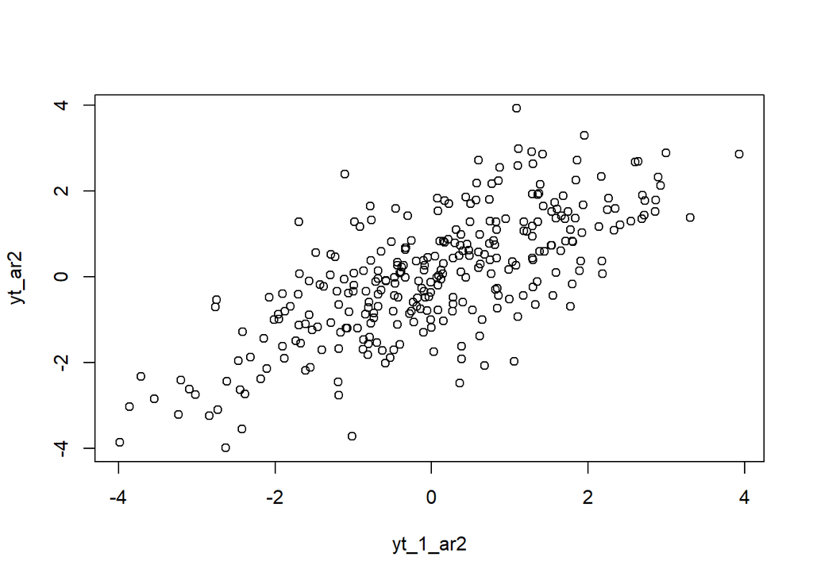

```r
yt_ar2 <- ar2[-1]
yt_1_ar2 <- ar2[-300]
plot(y=yt_ar2, x=yt_1_ar2)
```

### 2.4.2 $Y_t$ dengan $Y_{t-2}$

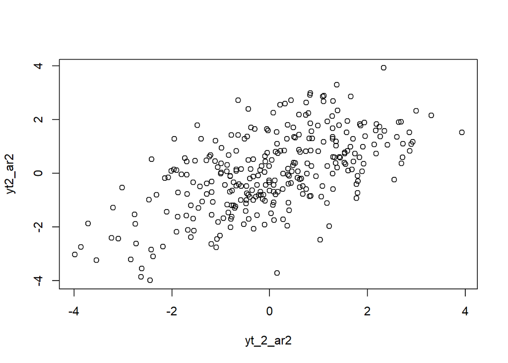

```r
yt2_ar2 <- ar2[-c(1,2)]
yt_2_ar2 <- ar2[-c(299,300)]
plot(y=yt2_ar2, x=yt_2_ar2)
```

### 2.4.3 $Y_t$ dengan $Y_{t-3}$

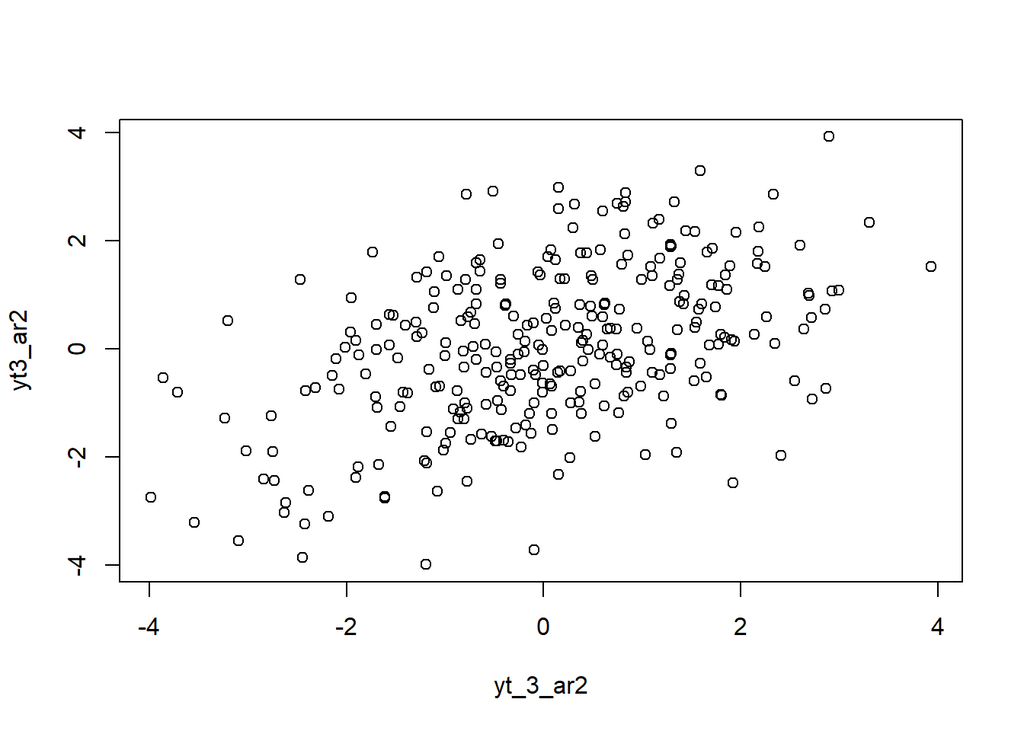

```r
yt3_ar2 <- ar2[-c(1,2,3)]
yt_3_ar2 <- ar2[-c(298,299,300)]
plot(y=yt3_ar2, x=yt_3_ar2)
```

Berdasarkan ketiga scatterplot tersebut, terlihat **hubungan positif** antara **$Y_t$ dengan $Y_{t-1}$, $Y_{t-2}$, maupun $Y_{t-3}$**, sesuai dengan sifat proses AR yang autokorelasinya *tails off* (tidak langsung terputus di satu lag tertentu).

## 2.5 Autokorelasi AR(2)

### 2.5.1 Autokorelasi dari Data Bangkitan (Empiris)

```r
cor(yt_ar2, yt_1_ar2)     # lag 1
```

```
## [1] 0.7181941
```

```r
cor(yt2_ar2, yt_2_ar2)    # lag 2
```

```
## [1] 0.5889847
```

```r
cor(yt3_ar2, yt_3_ar2)    # lag 3
```

```
## [1] 0.4630342
```

### 2.5.2 Autokorelasi Teoritis

Untuk AR(2), autokorelasi teoritis dicari melalui persamaan Yule-Walker:

$$\rho_1=\frac{\phi_1}{1-\phi_2}, \quad
\rho_2=\phi_2+\phi_1\rho_1, \quad
\rho_3=\phi_1\rho_2+\phi_2\rho_1$$

```r
ARMAacf(ar=c(0.5,0.2), lag.max=3, pacf=FALSE)
```

```
##       0       1       2       3
## 1.00000 0.62500 0.51250 0.38125
```

Terlihat bahwa nilai **autokorelasi hasil simulasi mendekati nilai autokorelasi teoritis** di atas.

# 3 Proses ARMA(2,2)

Proses ARMA(2,2) dengan $\theta_1=0.4$, $\theta_2=0.6$, $\phi_1=0.5$, $\phi_2=0.2$:

$$Y_t = e_t + \phi_1 Y_{t-1} + \phi_2 Y_{t-2} + \theta_1 e_{t-1} +
\theta_2 e_{t-2}$$

## 3.1 Pembangkitan Manual

```r
set.seed(1234)
n <- length(wn)
arma22 <- c(1:n)
arma22[1] <- wn[1]
arma22[2] <- wn[2] + 0.5*arma22[1] + 0.4*wn[1]
for (i in 3:n) {
  arma22[i] <- wn[i] + 0.5*arma22[i-1] + 0.2*arma22[i-2] + 0.4*wn[i-1] + 0.6*wn[i-2]
}
arma22
```

```
##   [1] -1.20706575 -0.80892993 -0.17470469 -1.99460202 -0.89073163 -1.57399907
##   [7] -1.07998865 -1.32768845 -2.00779067 -2.71323077 -2.93005255 -3.73095865
##  [13] -3.91341393 -3.54797330 -2.03714419 -1.41597933 -1.09484577 -2.01238927
##  [19] -2.73341934 -0.23493827 -0.06603372  0.93244599 -0.10335305  0.12377143
##  [25] -0.73299809 -1.79168410 -1.46320006 -2.75261323 -1.74869379 -2.98106689
##  [31] -1.12143708 -1.75317514 -1.33917373 -2.09061181 -3.56840137 -4.32233453
##  [37] -6.49939098 -7.02774300 -6.95246462 -6.26999191 -3.43892795 -3.74184510
##  [43] -2.97183210 -3.49823956 -3.96329426 -4.21591919 -4.99194641 -5.61517880
##  [49] -5.49499207 -5.32810453 -6.08211879 -5.70927870 -6.49640186 -6.19782008
##  [55] -5.63181852 -4.16631847 -1.43386885 -1.32659106  1.33518944 -0.57718024
##  [61]  1.13545859  2.56923457  2.89049812  2.80495288  1.68426164  2.77538380
##  [67]  1.29220742  3.17981522  3.04188011  3.84589812  3.47054592  2.25362466
##  [73]  1.27634579  1.31729358  3.02358707  2.83893413  1.81428668  0.10302896
##  [79] -0.45121970 -0.85290753 -0.66635425 -0.93510416 -2.14779642 -2.08562341
##  [85] -1.51503473 -0.24121274  0.91556687  0.64537308  0.48311177 -1.14217407
```

[output cut: 35 more lines]

## 3.2 Pembangkitan dengan `arima.sim()`

```r
set.seed(1234)
arma22.sim <- arima.sim(list(order=c(2,0,2), ar=c(0.5,0.2), ma=c(0.4,0.6)), n=300)
arma22.sim
```

```
## Time Series:
## Start = 1
## End = 300
## Frequency = 1
##   [1] -2.75189059 -1.74814288 -2.98064692 -1.12111691 -1.75293106 -1.33898765
##   [7] -2.09046996 -3.56829323 -4.32225209 -6.49932813 -7.02769509 -6.95242810
##  [13] -6.26996407 -3.43890672 -3.74182891 -2.97181976 -3.49823015 -3.96328709
##  [19] -4.21591372 -4.99194225 -5.61517562 -5.49498965 -5.32810268 -6.08211738
##  [25] -5.70927763 -6.49640104 -6.19781946 -5.63181804 -4.16631811 -1.43386858
##  [31] -1.32659085  1.33518960 -0.57718012  1.13545868  2.56923465  2.89049818
##  [37]  2.80495292  1.68426168  2.77538382  1.29220743  3.17981524  3.04188012
##  [43]  3.84589813  3.47054592  2.25362466  1.27634579  1.31729358  3.02358708
##  [49]  2.83893413  1.81428668  0.10302896 -0.45121970 -0.85290753 -0.66635425
##  [55] -0.93510416 -2.14779642 -2.08562341 -1.51503473 -0.24121274  0.91556687
##  [61]  0.64537308  0.48311177 -1.14217407 -1.12039092 -1.27141453  0.91636167
```

[output cut: 39 more lines]

## 3.3 Karakteristik ARMA(2,2)

### 3.3.1 Plot Time Series

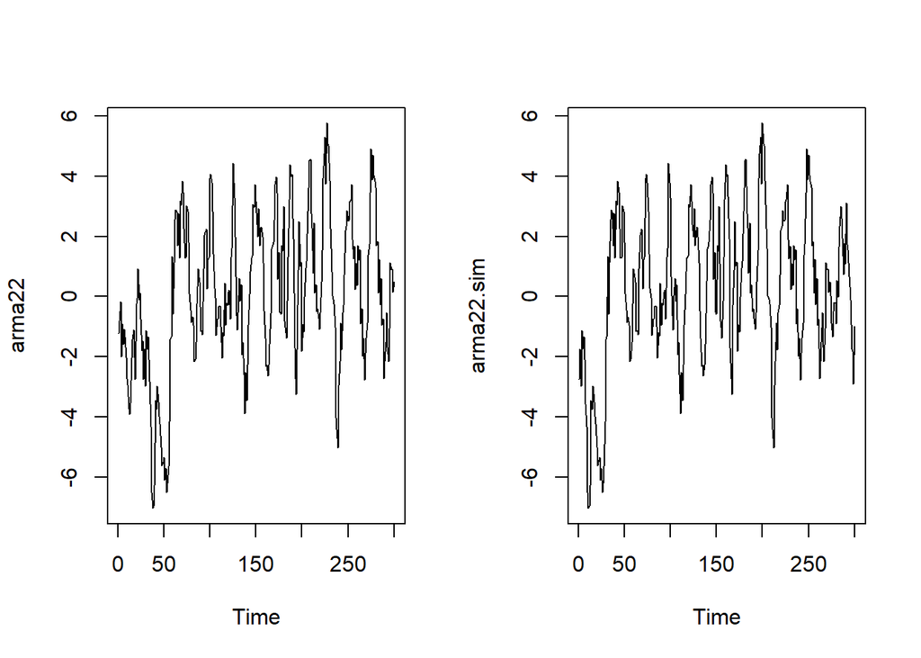

```r
par(mfrow = c(1, 2))
ts.plot(arma22)
ts.plot(arma22.sim)
```

```r
par(mfrow = c(1, 1))
```

Berdasarkan plot time series tersebut, terlihat bahwa data cenderung berfluktuasi di sekitar rataan konstan, sehingga data **stasioner dalam rataan**.

### 3.3.2 Plot ACF

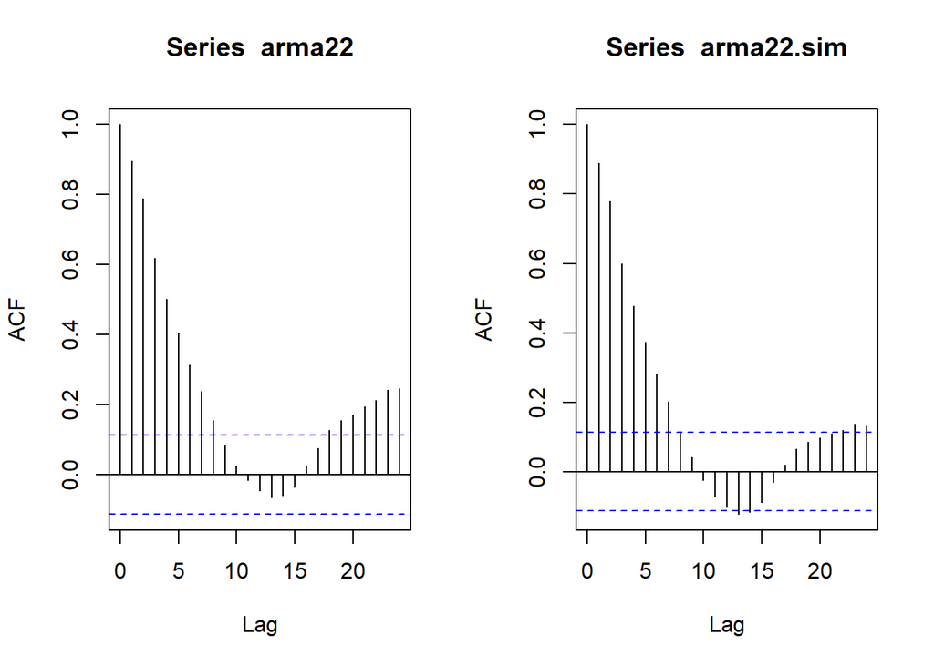

```r
par(mfrow = c(1, 2))
acf(arma22)
acf(arma22.sim)
```

```r
par(mfrow = c(1, 1))
```

Berdasarkan plot ACF tersebut, terlihat bahwa plot ACF cenderung *tails off*, sesuai dengan sifat proses ARMA.

### 3.3.3 Plot PACF

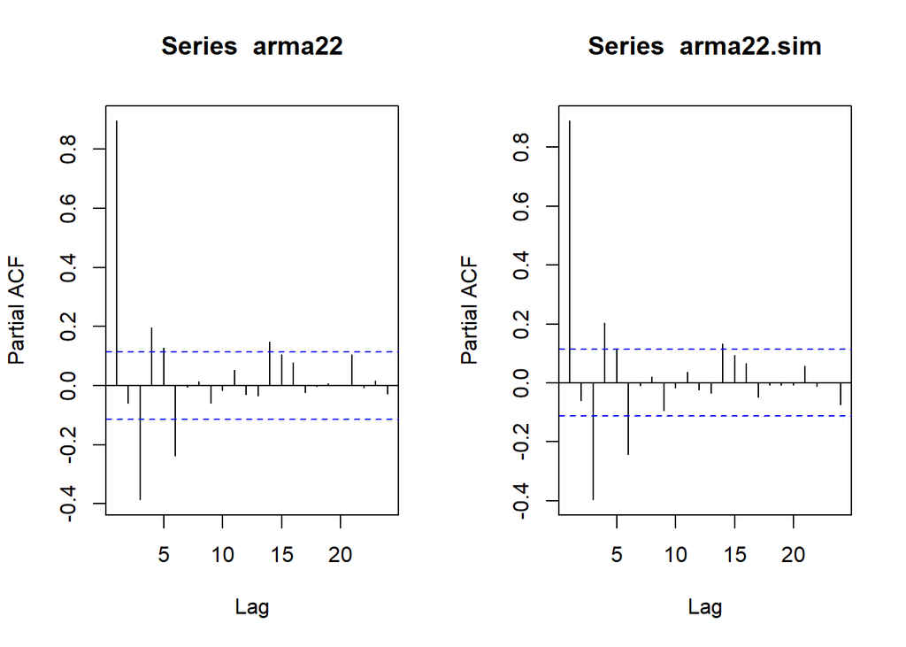

```r
par(mfrow = c(1, 2))
pacf(arma22)
pacf(arma22.sim)
```

```r
par(mfrow = c(1, 1))
```

Berdasarkan plot PACF tersebut, terlihat bahwa plot PACF juga cenderung *tails off*, sesuai dengan sifat proses ARMA.

### 3.3.4 Plot EACF

```r
TSA::eacf(arma22)
```

```
## AR/MA
##   0 1 2 3 4 5 6 7 8 9 10 11 12 13
## 0 x x x x x x x x o o o  o  o  o
## 1 o x o o o o x o o o o  o  o  o
## 2 x x o o o o x o o o o  o  o  o
## 3 x x o x o o x o o o o  o  o  o
## 4 x x x x o o x o o o o  o  o  o
## 5 x x x x x x x o o o o  o  o  o
## 6 o o x o x x o o o o o  o  o  o
## 7 o o x o x x o x o o o  o  o  o
```

```r
TSA::eacf(arma22.sim)
```

```
## AR/MA
##   0 1 2 3 4 5 6 7 8 9 10 11 12 13
## 0 x x x x x x x o o o o  o  x  o
## 1 o x o o o o x o o o o  o  o  o
## 2 x x o o o o o o o o o  o  o  o
## 3 x x x x o o o o o o o  o  o  o
## 4 x x x x o o o o o o o  o  o  o
## 5 x x x x x x x o o o o  o  o  o
## 6 o o x o x x o o o o o  o  o  o
## 7 x o x x x x o x o o o  o  o  o
```

Berdasarkan pola segitiga nol pada plot EACF, segitiga nol berada pada **ordo AR(2) dan ordo MA(2)** sesuai dengan model yang dibangkitkan.

## 3.4 Scatterplot Antar Lag

### 3.4.1 $Y_t$ dengan $Y_{t-1}$

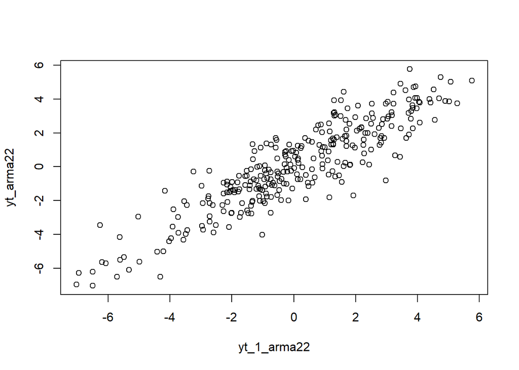

```r
yt_arma22 <- arma22[-1]
yt_1_arma22 <- arma22[-300]
plot(y=yt_arma22, x=yt_1_arma22)
```

### 3.4.2 $Y_t$ dengan $Y_{t-2}$

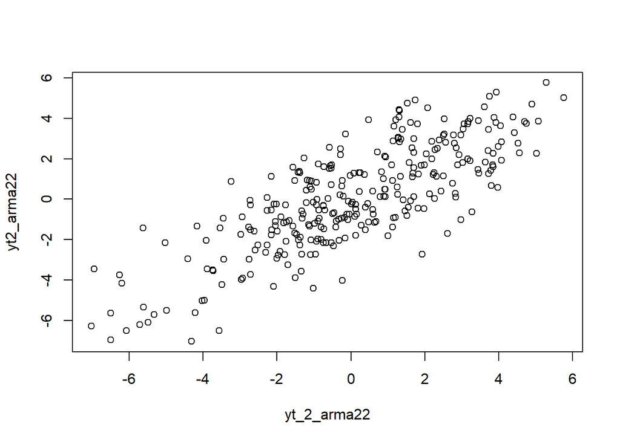

```r
yt2_arma22 <- arma22[-c(1,2)]
yt_2_arma22 <- arma22[-c(299,300)]
plot(y=yt2_arma22, x=yt_2_arma22)
```

### 3.4.3 $Y_t$ dengan $Y_{t-3}$

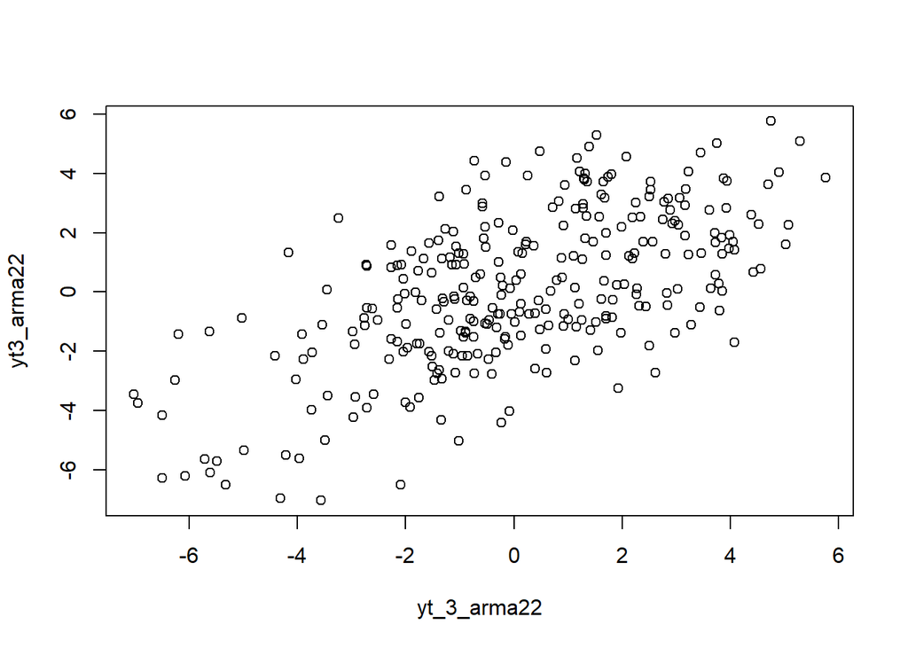

```r
yt3_arma22 <- arma22[-c(1,2,3)]
yt_3_arma22 <- arma22[-c(298,299,300)]
plot(y=yt3_arma22, x=yt_3_arma22)
```

Berdasarkan ketiga scatterplot tersebut, terlihat hubungan positif antara $Y_t$ dengan lag-lag sebelumnya, konsisten dengan sifat *tails off* pada proses ARMA.

## 3.5 Autokorelasi ARMA(2,2)

### 3.5.1 Autokorelasi dari Data Bangkitan (Empiris)

```r
cor(yt_arma22, yt_1_arma22)     # lag 1
```

```
## [1] 0.8955216
```

```r
cor(yt2_arma22, yt_2_arma22)    # lag 2
```

```
## [1] 0.7899614
```

```r
cor(yt3_arma22, yt_3_arma22)    # lag 3
```

```
## [1] 0.6195458
```

### 3.5.2 Autokorelasi Teoritis

Autokorelasi teoritis ARMA(2,2) dihitung menggunakan fungsi `ARMAacf()` di R (perhitungan manual ARMA campuran cukup kompleks karena melibatkan komponen AR dan MA sekaligus):

```r
ARMAacf(ar=c(0.5,0.2), ma=c(0.4,0.6), lag.max=3, pacf=FALSE)
```

```
##         0         1         2         3
## 1.0000000 0.8591993 0.7491908 0.5464353
```

Terlihat bahwa nilai **autokorelasi hasil simulasi mendekati** nilai **autokorelasi teoritis** pada masing-masing lag.